# W3cubDocs

## Examples using `sklearn.svm.LinearSVC`

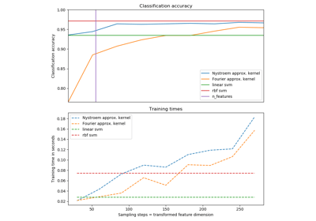

Explicit feature map approximation for RBF kernels

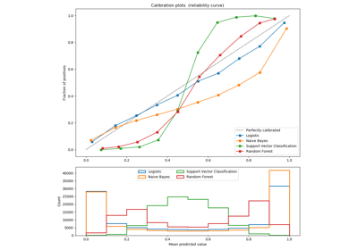

Comparison of Calibration of Classifiers

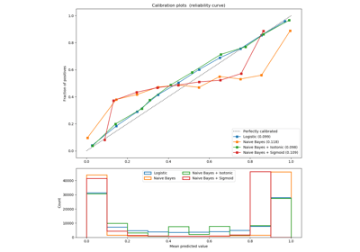

Probability Calibration curves

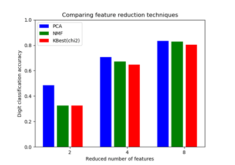

Selecting dimensionality reduction with Pipeline and GridSearchCV

[figure not shown]

Column Transformer with Heterogeneous Data Sources

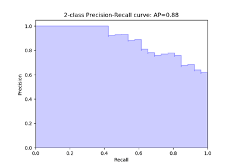

Precision-Recall

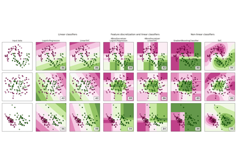

Feature discretization

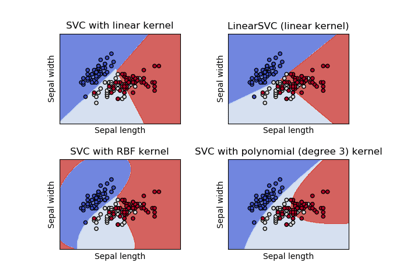

Plot different SVM classifiers in the iris dataset

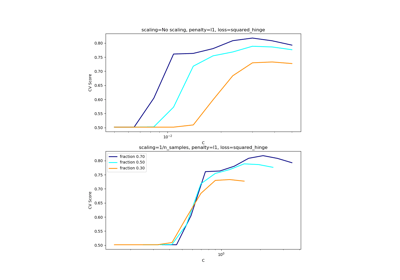

Scaling the regularization parameter for SVCs

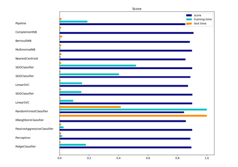

Classification of text documents using sparse features